# M5_W2_Reproducible_Research_Markdown_and_knitr

Alexander Cormack

2023-02-27

# Markdown and knitr

## Coding Standards for R

1. Always use text files / text editor
2. Indent your code
   - indenting improves readability
   - suggested: indents of 4 spaces at a minimum; 8 spaces ideal
3. Limit the width of your code (80 columns?)
   - fixing line length prevents lots of nesting and very long functions
4. Limit the length of individual functions
   - limit it to one basic activity, i.e. only read data or process data, or fit a model or print some output
   - helps with debugging

## Introduction to Markdown

### What is markdown?

*Markdown is a text-to-HTML conversion tool for web writers. Markdown allows you to write using an easy-to-read, easy-to-write plain text format, then convert it to structurally valid XHTML (or HTML).*

John Gruber, creator of markdown

### Markdown syntax

- Italics: wrap text in single asterisks or underscores
- Bold: wrap text in double asterisks or underscores
- Italics and bold: wrap text in triple asterisks or asterisks and underscores
- Strikethrough: wrap text in double tildes
- Headings: use hashtags to create 1st, 2nd … 6th level headings
- Bulleted lists: use a dash (or any other character consistently across the list) and a space at the beginning of the line
- Numbered lists: use a number, a full stop and a space
- Indents: at least one leading space at the beginning of a line - introduces a blank line above and an indent by the number of spaces
- Links: enclose the link text in square brackets followed by the link address in round brackets
- Advanced linking: enclose the link text in square brackets immediately followed by a number in square brackets. Later on in the document list all the links with the number in square brackets followed by a colon followed by the link address followed by the link text in quotation marks
- Newlines: requires a double space at the end of a line
- See the Github cheatsheet for the following formatting tips:
  - images
  - code and syntax highlighting
  - footnotes
  - tables
  - blockquotes
  - inline HTML
  - horizontal rule

[The Official Markdown Documentation](https://www.markdownguide.org)  
[Github’s Markdown Cheatsheet](https://github.com/adam-p/markdown-here/wiki/Markdown-Cheatsheet)

## R Markdown

### What is markdown?

- Created by [John Gruber](https://daringfireball.net) and Aaron Schwartz
- A simplified version of “markup” languages
- Allows one to focus on writing as opposed to formatting
- Simple/minimal intuitive formatting elements
- Easily converted to valid HTML (and other formats) using existing tools
- Complete information is available at http://daringfireball.net/projects/markdown/
- Some background information at http://daringfireball.net/2004/03/dive_into_markdown

### What is R markdown?

- R markdown is the integration of R code with markdown
- Allows one to create documents containing “live” R code
- R code is evaluated as part of the processing of the markdown
- Results from R code are inserted into markdown document
- A core tool in **literate statistical programming**
- R markdown can be converted to standard markdown using the knitr package in R
- Markdown can be converted to HTML using the markdown package in R
- Any basic text editor can be used to create a markdown document; no special editing tools needed
- The R markdown –> markdown –> HTML work flow can be easily managed using RStudio (but not required)

## knitr (Part 1)

### Problems, problems

- Authors must undertake considerable effort to put data/results on the web
- Readers must download data/results individually and piece together which data go with which code sections, etc.
- Authors/readers must manually interact with websites
- There is no single document to integrate data analysis with textual representations; i.e. data, code, and text are not linked

### Literate statistical programming

- Original idea comes from Don Knuth
- An article is a stream of **text** and **code**
- Analysis code is divided into text and code “chunks”
- Presentation code formats results (tables, figures, etc.)
- Article text explains what is going on
- Literate programs are **weaved** to produce human-readable documents and **tangled** to produce machine-readable documents
- literate programming is a general concept. We need
  - a documentation language
  - a programming language
- The original **Sweave** system developed by Friedrich Leisch used LaTeX and R
- **knitr** supports a variety of documentation languages

### How do I make my work reproducible?

- Decide to do it (ideally from the start)
- Keep track of things, perhaps with a version control system to track snapshots/changes
- Use software whose operation can be coded
- Don’t save output
- Save data in non-proprietary formats

### Literate programming: pros

- Text and code all in one place, logical order
- Data, results automatically updated to reflect external changes
- Code is live–automatic “regression test” when building a document

### Litereate programming: cons

- Text and code all in one place: can make documents difficult to read, especially if there is a lot of code
- Can be substantially slow down processing of documents (although there are tools to help)

## knitr (Part 2)

### What is knitr?

- An R package written by Yihui Xie (while he was a grad student at Iowa State)
  - available on CRAN
- Supports R markdown, LaTeX and HTML as documentation languages
- Can export to PDF, HTML
- Built right into RStudio for your convenience

### Requirements

- A recent version of R
- A text editor (the one that comes with RStudio is OK)
- Some support packages also available on CRAN
- Some knowledge of markdown, LaTeX or HTML
- We will use markdown here

### What is markdown?

- A simplified version of “markup” languages
- No special editor required
- Simple, intuitive formatting elements
- Complete information available at http://goo.gl/MUt9i5

### What is knitr good for?

- Manuals
- Short/medium-length technical documents
- Tutorials
- Reports (esp. if generated periodically)
- Data pre-processing documents/summaries

### What is knitr NOT good for?

- Very long research articles
- Complex time-consuming computations
- Documents that require precise formatting

## knitr (Part 3)

This is a demonstration on how to create a knitr document.

### A few notes

```r
## R code goes here
```

- By default code in a code chunk is echoed, as will the results of the computation (if there are results to print)

## knitr (Part 4)

### Processing of knitr documents - what happens under the hood

- You write the R markdown document(.Rmd)
- knitr produces a markdown document (.md)
- knitr converts the markdown document into HTML (by default)
- .Rmd -> .md -> .html
- You should NOT edit (or save) the .md or .html documents until you are finished

If you don’t want the code to be seen in the output file, use echo=FALSE in the codechunk name

```
## [1] 0.1088874
```

If you don’t want to see the results you can use results=“hide” in the codechunk name

```r
set.seed(1)
x <- rnorm(100)
mean(x)
```

### Inline text computations

We can write some code, use echo=FALSE to hide the code in the output document, and then perform inline computations from the code by placing the results of the computations between backticks … as shown in the next sentence:

The current time is Sat Mar 04 13:56:51 2023. My favourite random number is -0.6203667.

### Making tables with xtable

Some introductory code

```r
library(datasets)
data(airquality)
fit <- lm(Ozone ~ Wind + Temp + Solar.R, data = airquality)
```

Here is a talbe of regression coefficients:

```r
library(xtable)
xt <- xtable(summary(fit))
print(xt, type = "html")
```

|  | Estimate | Std. Error | t value | Pr(>\|t\|) |
| --- | --- | --- | --- | --- |
| (Intercept) | -64.3421 | 23.0547 | -2.79 | 0.0062 |
| Wind | -3.3336 | 0.6544 | -5.09 | 0.0000 |
| Temp | 1.6521 | 0.2535 | 6.52 | 0.0000 |
| Solar.R | 0.0598 | 0.0232 | 2.58 | 0.0112 |

### Setting global options

- Sometimes we want to set options for **every** code chunk that are different from the defaults
- For example, we may want to suppress all code echoing and results output
- We have to write some code to set these global options
- You need to write some code at the beginning of the markdown document

In the example below, see how the code to create the data is printed by setting echo equal to true, but by default the code for making the plot is hidden.

First simulate data

```r
x <- rnorm(100); y <- x + rnorm(100, sd = 0.5)
```

Here is a scatterplot of the data.

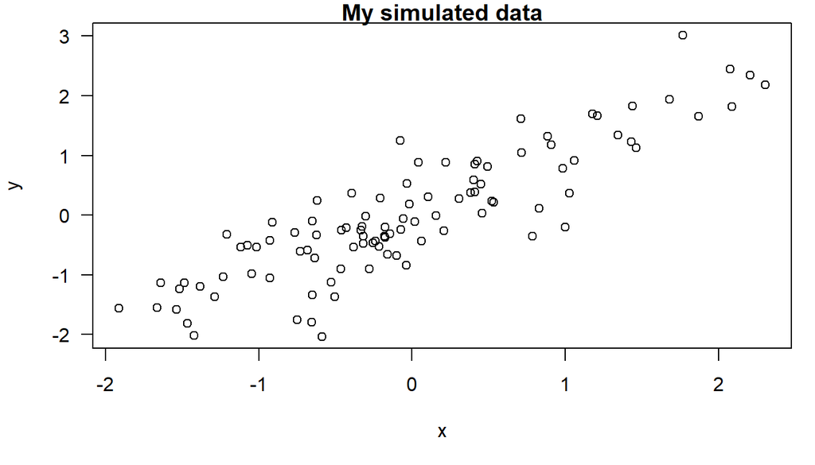

### Sommon common options

- Output
  - results: “asis”, “hide”
  - echo: TRUE, FALSE
- Figures
  - fig.height: numeric
  - fig.width: numeric

### Caching complications

- What if one chunk takes a long time to run?
- All chunks have to be re-computed every time you re-knit the file
- The cache=TRUE option can be set on a chunk-by-chunk basis to store results of computation
- After the first run, results are loaded from cache

### Caching caveats

- If the data or code (or anything external) changes, you need to re-run the cached code
- Dependencies are not checked explicitly
- Chunks with significant *side effects* may not be cacheable

### Summary

- Literate statistical programming can be a useful way to put text, code, data, output all in one document
- knitr is a powerful tool for integratinig code and text in a simple document format